# Gesture Recognition thru Machine Learning

**Machine learning algorithms applied to glove sensor values to derive the categories.**

Includes the analysis of the following unsupervised algorithms:

1. PCA

Includes the analysis of the following supervised algorithms:

1. SVC
2. K Neighbors Classifier
3. Decision Tree Classifier
4. Random Forest Classifier
5. Ada Boost Classifier
6. Gaussian Naive Bayes
7. Linear Discrimninant Analysis
8. Quadratic Discriminant Analysis

```python
%pylab inline
#Essentials
import pandas as pd
import string

#Preprocessing
from sklearn.preprocessing import StandardScaler
from sklearn.cross_validation import train_test_split

#Libraries for the estimators
from sklearn.decomposition import PCA
from sklearn.svm import SVC
from sklearn import linear_model
from sklearn.neighbors import KNeighborsClassifier
from sklearn.tree import DecisionTreeClassifier
from sklearn.ensemble import RandomForestClassifier, AdaBoostClassifier
from sklearn.naive_bayes import GaussianNB
from sklearn.discriminant_analysis import LinearDiscriminantAnalysis
from sklearn.discriminant_analysis import QuadraticDiscriminantAnalysis

#For SVC
from sklearn.cross_validation import cross_val_score, KFold
from scipy.stats import sem
from sklearn import metrics

#Model persistence
from sklearn.externals import joblib

#Analysis
import seaborn as sb
```

```
WARNING: pylab import has clobbered these variables: ['figure', 'clf', 'cm']
`%matplotlib` prevents importing * from pylab and numpy
```

```python
import pandas as pd

def data_cleaning(file):
    feature_names = ['fPinky', 'fRing', 'fMiddle', 'fIndex', 'fThumb', 'c1', 'c2', 'c3', 'c4', 'aX', 'aY', 'aZ', 'gX', 'gY', 'gZ', 'label']
    a = pd.read_excel(file, convert_float=True, names=feature_names)
    a.dropna(how='any',inplace=True)
    a.to_csv(file.split(".")[0] + ".csv", index=False)

data_cleaning("5.xlsx")
```

```python
#Data Parameters
target_names = [i for i in string.ascii_uppercase]
target_names.extend(['_', 'Enter', 'Stop'])
feature_names = ['label','fPinky', 'fRing', 'fMiddle', 'fIndex', 'fThumb', 'c1', 'c2', 'c3', 'c4', 'aX', 'aY', 'aZ', 'gX', 'gY', 'gZ']

data = pd.concat([pd.read_csv(str(i)+".csv") for i in range(1,5)])
sl = data.sample(frac=0.33).reset_index(drop=True)
sl_data = sl.iloc[:,:-1]
sl_target = sl['label'].apply(lambda x: target_names.index(x)).values


#Extra evaluations
# sl.describe()
# sb.pairplot(sl.dropna(), hue='label')
# sl.loc[sl['label'] == 'A', 'fThumb'].hist()

X, y = sl_data, sl_target
#Standardize X because of different scaling from different sensors
X_std = StandardScaler().fit_transform(X)
```

```python
def plot_scatter(X_estimator, letter, title):
    plt.figure()
    fig = matplotlib.pyplot.gcf()
    fig.set_size_inches(12, 8)
    for i in range(len(target_names)):
        px = X_estimator[y == i, 0]
        py = X_estimator[y == i, 1]
        if i is letter :
            plt.scatter(px, py, c='red', zorder=2)
        else:
            plt.scatter(px, py, c='silver', alpha=0.5, zorder=1)
        plt.legend(target_names)
        plt.title("PCA 2 Components plot for letter %s" % target_names[letter])
```

### Principal Component Analysis (PCA)

Identifies the combination of attributes (principal components, or directions in the feature space) that account for the most variance in the data. Here we plot the different samples on the 2 first principal components.

```
explained variance ratio (first 15 components): [  1.71911325e-01   1.10384174e-01   1.04475489e-01   9.09918130e-02
   8.79309442e-02   8.01901007e-02   7.17909959e-02   6.96944812e-02
   6.54944652e-02   5.66672713e-02   5.29822560e-02   2.25402425e-02
   1.49464420e-02   4.96358584e-34   1.06250101e-37]
```

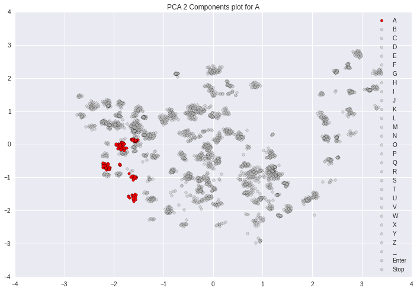

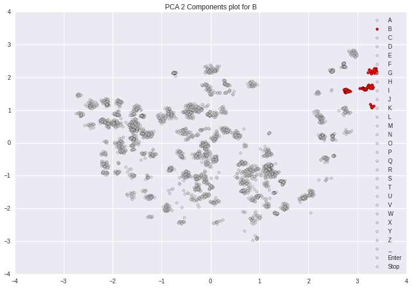

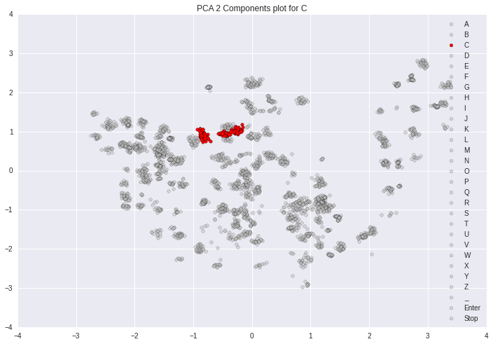

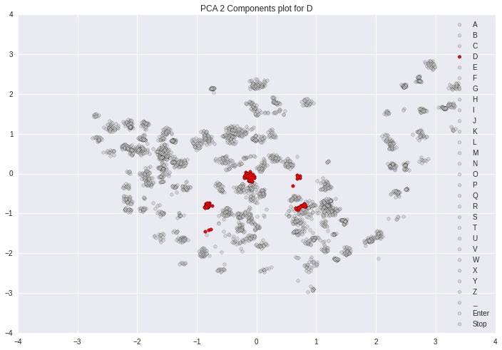

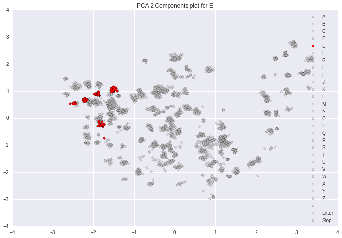

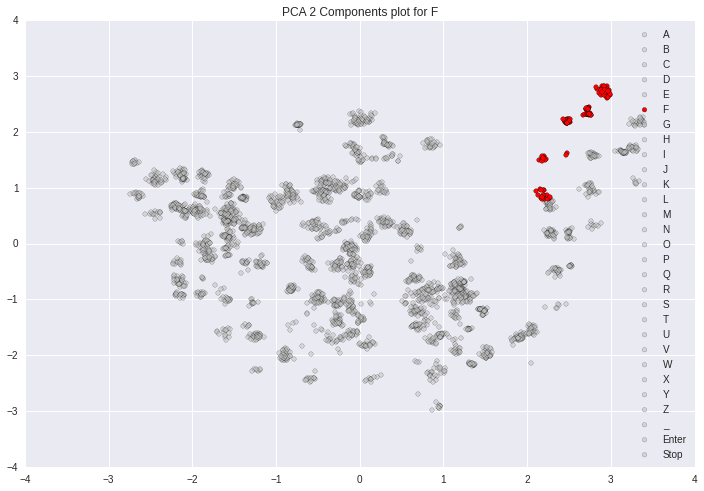

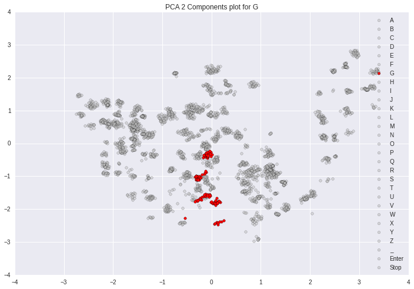

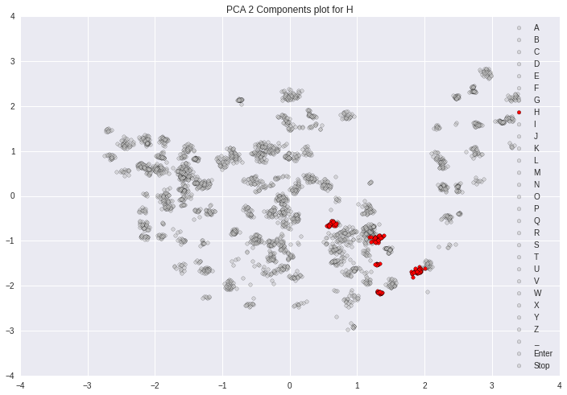

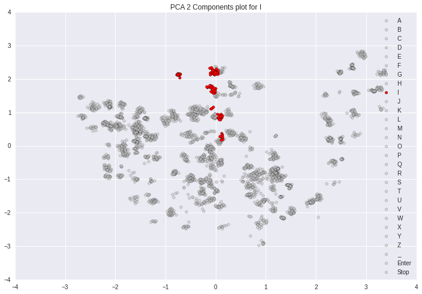

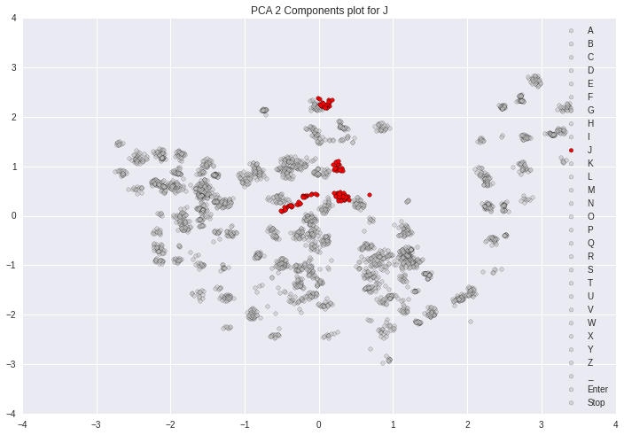

```python
n = 15
pca = PCA(n_components=n)
X_pca = pca.fit(X_std).transform(X_std)

for i in range(10):
    plot_scatter(X_pca, i, "PCA of the dataset")

print('explained variance ratio (first %s components): %s' % (str(n), str(pca.explained_variance_ratio_)))
```

### Linear Discriminant Analysis (LDA)

Identifies attributes that account for the most variance between classes. In particular, LDA, in contrast to PCA, is a supervised method, using known class labels.

### SVM (Support Vector Machine)

```
* supervised learning method that try to obtain hyperplanes that separate classes
* Effective when working with high-dimensional data aka lot of features
* Efficient in space
* Calculation intensive
* Doesn't return numerical indicator on how confident it is in predicting
```

### SVC (Support Vector Classifier) for classification

Adjustment of parameters Kernel functions: different similarity measures between instances. By default, the SVC class uses the rbf kernel, which allows us to model nonlinear problems. To start, we will use the simplest kernel, the linear one. C and gamma can also be checked

```python
X_train, X_test, y_train, y_test = train_test_split(X_std, y, test_size=0.25, random_state=0)

def evaluate_cross_validation(clf, X, y, K):
    # create a k-fold croos validation iterator
    cv = KFold(len(y), K, shuffle=True, random_state=0)
    # by default the score used is the one returned by score method of the estimator (accuracy)
    scores = cross_val_score(clf, X, y, cv=cv)
    print(scores)
    print(("Mean score: {0:.3f} (+/-{1:.3f})").format(np.mean(scores), sem(scores)))

def train_and_evaluate(clf, X_train, X_test, y_train, y_test):
    clf.fit(X_train, y_train)
    print("Accuracy on training set:")
    print(clf.score(X_train, y_train))
    print("Accuracy on testing set:")
    print(clf.score(X_test, y_test))
    y_pred = clf.predict(X_test)
    print("Classification Report:")
    print(metrics.classification_report(y_test, y_pred))
    print("Confusion Matrix:")
    print(metrics.confusion_matrix(y_test, y_pred))
    return clf
```

```python
names = ["Nearest Neighbors", "Linear SVM", "RBF SVM", "Decision Tree",
         "Random Forest", "AdaBoost", "Naive Bayes", "Linear Discriminant Analysis",
         "Quadratic Discriminant Analysis"]
classifiers = [
    KNeighborsClassifier(3),
    SVC(kernel="linear"),
    SVC(gamma=2),
    DecisionTreeClassifier(max_depth=5),
    RandomForestClassifier(max_depth=5, n_estimators=10, max_features=1),
    AdaBoostClassifier(),
    GaussianNB(),
    LinearDiscriminantAnalysis(),
    QuadraticDiscriminantAnalysis()]

print("------------  SUMMARY OF CLASSIFIERS  ------------")
for name, clf in zip(names, classifiers):
    clf.fit(X_train, y_train)
    print("%s: %s" % (name, clf.score(X_test, y_test)))

clf_predictor = []
for name, clf in zip(names, classifiers):
    print("\n################ %s ################" % name)
    clf.fit(X_train, y_train)
    evaluate_cross_validation(clf, X_train, y_train, 5)
    clf_predictor.append(train_and_evaluate(clf, X_train, X_test, y_train, y_test))
```

```
Nearest Neighbors: 0.966551326413
Linear SVM: 0.9815455594
RBF SVM: 0.980392156863
Decision Tree: 0.61476355248
Random Forest: 0.889273356401
AdaBoost: 0.117647058824
Naive Bayes: 0.83506343714
Linear Discriminant Analysis: 0.813148788927
Quadratic Discriminant Analysis: 0.666666666667

################ Nearest Neighbors ################
[ 0.96538462  0.96153846  0.93653846  0.94412331  0.97495183]
Mean score: 0.957 (+/-0.007)
Accuracy on training set:
0.985758275597
Accuracy on testing set:
0.966551326413
Classification Report:
             precision    recall  f1-score   support

          0       0.94      1.00      0.97        34
          1       1.00      1.00      1.00        34
          2       0.95      0.88      0.91        40
          3       1.00      1.00      1.00        32
          4       0.95      0.95      0.95        37
          5       1.00      0.97      0.98        31
          6       1.00      1.00      1.00        39
          7       0.94      1.00      0.97        29
          8       0.96      0.93      0.94        27
          9       0.87      0.97      0.92        34
         10       0.93      0.96      0.95        27
         11       1.00      1.00      1.00        35
         12       0.93      0.84      0.88        31
         13       1.00      1.00      1.00        35
         14       0.85      1.00      0.92        35
         15       0.97      1.00      0.98        30
         16       0.97      0.97      0.97        39
         17       1.00      1.00      1.00        32
         18       1.00      0.97      0.98        31
         19       1.00      0.96      0.98        24
```

[output cut: 245 more lines]

```
 [ 0  0  0  0  0  0  0  0  0  0  0  0  0  0  0  0  0  0  0  0  0 30  0  0
   0  0  0]
 [ 0  0  0  0  0  0  0  0  0  0  0  0  0  0  0  0  0  0  0  0  0  0 37  0
   0  0  0]
 [ 0  0  0  0  0  0  0  0  0  0  0  0  1  0  0  0  0  0  0  0  0  0  0 37
   0  0  0]
 [ 0  0  0  0  0  0  0  0  0  0  0  0  0  0  0  0  0  0  0  0  0  0  0  0
  28  1  0]
 [ 0  0  0  0  0  0  0  0  0  0  0  0  0  0  0  0  1  0  0  0  0  0  0  0
   0 35  0]
 [ 0  0  0  0  0  0  0  0  0  0  0  0  0  0  0  0  0  0  0  0  0  0  0  0
   0  0  6]]

################ Decision Tree ################
[ 0.58846154  0.61923077  0.48076923  0.44123314  0.54527938]
```

```
Mean score: 0.535 (+/-0.033)
Accuracy on training set:
0.611239414935
Accuracy on testing set:
0.615916955017
Classification Report:
             precision    recall  f1-score   support

          0       0.19      1.00      0.31        34
          1       1.00      1.00      1.00        34
          2       1.00      0.82      0.90        40
          3       0.39      0.75      0.51        32
          4       0.00      0.00      0.00        37
          5       1.00      1.00      1.00        31
          6       1.00      1.00      1.00        39
          7       0.96      0.83      0.89        29
          8       0.63      1.00      0.77        27
          9       1.00      0.53      0.69        34
         10       0.26      1.00      0.41        27
         11       0.61      1.00      0.76        35
         12       0.00      0.00      0.00        31
         13       0.81      1.00      0.90        35
         14       0.79      0.97      0.87        35
         15       0.67      0.97      0.79        30
         16       1.00      0.38      0.56        39
         17       1.00      0.91      0.95        32
         18       0.00      0.00      0.00        31
         19       0.00      0.00      0.00        24
         20       0.00      0.00      0.00        35
         21       0.00      0.00      0.00        30
         22       1.00      1.00      1.00        37
         23       0.00      0.00      0.00        38
         24       1.00      1.00      1.00        29
         25       0.00      0.00      0.00        36
         26       0.00      0.00      0.00         6

avg / total       0.56      0.62      0.55       867

Confusion Matrix:
[[34  0  0  0  0  0  0  0  0  0  0  0  0  0  0  0  0  0  0  0  0  0  0  0
```

[output cut: 236 more lines]

```
   0  0  0]
 [ 0  0  0  0  0  0  0  0  0  0 38  0  0  0  0  0  0  0  0  0  0  0  0  0
   0  0  0]
 [ 0  0  0  0  0  0  0  0 29  0  0  0  0  0  0  0  0  0  0  0  0  0  0  0
   0  0  0]
 [ 0  0  0  0  0  0  0  0  0  0 36  0  0  0  0  0  0  0  0  0  0  0  0  0
   0  0  0]
 [ 0  0  0  0  0  0  0  0  0  0  0  0  0  0  0  0  0  0  0  0  0  0  0  0
   0  0  6]]

################ Naive Bayes ################
[ 0.85961538  0.81730769  0.83269231  0.82080925  0.83622351]
Mean score: 0.833 (+/-0.007)
Accuracy on training set:
0.838337182448
```

```
Accuracy on testing set:
0.83506343714
Classification Report:
             precision    recall  f1-score   support

          0       0.97      1.00      0.99        34
          1       1.00      1.00      1.00        34
          2       0.63      1.00      0.78        40
          3       0.89      1.00      0.94        32
          4       0.79      1.00      0.88        37
          5       1.00      1.00      1.00        31
          6       1.00      1.00      1.00        39
          7       0.72      1.00      0.84        29
          8       0.62      0.78      0.69        27
          9       1.00      0.41      0.58        34
         10       0.59      1.00      0.74        27
         11       1.00      1.00      1.00        35
         12       0.53      1.00      0.70        31
         13       1.00      1.00      1.00        35
         14       1.00      0.37      0.54        35
         15       0.70      0.63      0.67        30
         16       0.94      0.79      0.86        39
         17       1.00      1.00      1.00        32
         18       1.00      0.35      0.52        31
         19       0.93      0.54      0.68        24
         20       1.00      0.23      0.37        35
         21       0.71      0.90      0.79        30
         22       1.00      1.00      1.00        37
         23       1.00      0.76      0.87        38
         24       0.69      1.00      0.82        29
         25       1.00      0.83      0.91        36
         26       1.00      1.00      1.00         6

avg / total       0.88      0.84      0.82       867

Confusion Matrix:
[[34  0  0  0  0  0  0  0  0  0  0  0  0  0  0  0  0  0  0  0  0  0  0  0
   0  0  0]
 [ 0 34  0  0  0  0  0  0  0  0  0  0  0  0  0  0  0  0  0  0  0  0  0  0
   0  0  0]
```

[output cut: 38 more lines]

```
 [ 0  0  0  0  0  0  0  0  0  0  3  0  0  0  0  0  0  0  0  0  0 27  0  0
   0  0  0]
 [ 0  0  0  0  0  0  0  0  0  0  0  0  0  0  0  0  0  0  0  0  0  0 37  0
   0  0  0]
 [ 0  0  1  0  0  0  0  0  0  0  0  0  8  0  0  0  0  0  0  0  0  0  0 29
   0  0  0]
 [ 0  0  0  0  0  0  0  0  0  0  0  0  0  0  0  0  0  0  0  0  0  0  0  0
  29  0  0]
 [ 0  0  0  4  0  0  0  0  0  0  0  0  0  0  0  0  2  0  0  0  0  0  0  0
   0 30  0]
 [ 0  0  0  0  0  0  0  0  0  0  0  0  0  0  0  0  0  0  0  0  0  0  0  0
   0  0  6]]

################ Linear Discriminant Analysis ################
[ 0.81153846  0.83269231  0.80961538  0.82851638  0.83044316]
```

```
Mean score: 0.823 (+/-0.005)
Accuracy on training set:
0.84064665127
Accuracy on testing set:
0.813148788927
Classification Report:
             precision    recall  f1-score   support

          0       0.92      1.00      0.96        34
          1       1.00      1.00      1.00        34
          2       0.86      0.90      0.88        40
          3       0.48      0.81      0.60        32
          4       0.82      0.84      0.83        37
          5       1.00      1.00      1.00        31
          6       0.87      0.69      0.77        39
          7       0.83      0.66      0.73        29
          8       0.75      0.78      0.76        27
          9       0.82      0.79      0.81        34
         10       0.65      0.89      0.75        27
         11       0.72      0.94      0.81        35
         12       0.77      0.87      0.82        31
         13       0.81      1.00      0.90        35
         14       0.88      0.83      0.85        35
         15       0.77      0.67      0.71        30
         16       0.83      0.62      0.71        39
         17       1.00      1.00      1.00        32
         18       0.71      0.81      0.76        31
         19       0.94      0.62      0.75        24
         20       0.73      0.46      0.56        35
         21       0.55      0.90      0.68        30
         22       1.00      1.00      1.00        37
         23       0.96      0.66      0.78        38
         24       1.00      1.00      1.00        29
         25       1.00      0.42      0.59        36
         26       1.00      1.00      1.00         6

avg / total       0.84      0.81      0.81       867

Confusion Matrix:
[[34  0  0  0  0  0  0  0  0  0  0  0  0  0  0  0  0  0  0  0  0  0  0  0
```

[output cut: 44 more lines]

```
   0  0  0]
 [ 0  0  0  0  0  0  0  0  0  0  0  0  5  8  0  0  0  0  0  0  0  0  0 25
   0  0  0]
 [ 0  0  0  0  0  0  0  0  0  0  0  0  0  0  0  0  0  0  0  0  0  0  0  0
  29  0  0]
 [ 0  0  0 15  0  0  1  0  0  0  0  0  0  0  0  0  5  0  0  0  0  0  0  0
   0 15  0]
 [ 0  0  0  0  0  0  0  0  0  0  0  0  0  0  0  0  0  0  0  0  0  0  0  0
   0  0  6]]

################ Quadratic Discriminant Analysis ################
[ 0.69038462  0.67307692  0.63846154  0.61271676  0.69942197]
Mean score: 0.663 (+/-0.016)
Accuracy on training set:
0.684372594303
```

```
Accuracy on testing set:
0.666666666667
Classification Report:
             precision    recall  f1-score   support

          0       0.84      0.47      0.60        34
          1       1.00      0.97      0.99        34
          2       1.00      0.53      0.69        40
          3       1.00      0.47      0.64        32
          4       0.78      0.76      0.77        37
          5       1.00      0.45      0.62        31
          6       1.00      0.15      0.27        39
          7       1.00      0.41      0.59        29
          8       0.00      0.00      0.00        27
          9       0.34      1.00      0.50        34
         10       1.00      0.22      0.36        27
         11       0.92      0.97      0.94        35
         12       1.00      0.97      0.98        31
         13       1.00      1.00      1.00        35
         14       0.96      0.69      0.80        35
         15       1.00      0.07      0.12        30
         16       0.39      0.97      0.55        39
         17       1.00      1.00      1.00        32
         18       1.00      0.42      0.59        31
         19       0.26      1.00      0.42        24
         20       0.81      0.97      0.88        35
         21       0.56      0.90      0.69        30
         22       0.95      0.51      0.67        37
         23       0.91      0.55      0.69        38
         24       1.00      1.00      1.00        29
         25       0.34      0.69      0.46        36
         26       1.00      1.00      1.00         6

avg / total       0.82      0.67      0.66       867

Confusion Matrix:
[[16  0  0  0  0  0  0  0  0  0  0  0  0  0  0  0  0  0  0 18  0  0  0  0
   0  0  0]
 [ 0 33  0  0  0  0  0  0  0  1  0  0  0  0  0  0  0  0  0  0  0  0  0  0
   0  0  0]
```

[output cut: 35 more lines]

```
   0  0  0]
 [ 0  0  0  0  0  0  0  0  0  0  0  0  0  0  0  0  0  0  0  0 34  1  0  0
   0  0  0]
 [ 0  0  0  0  0  0  0  0  0  0  0  0  0  0  0  0  0  0  0  0  3 27  0  0
   0  0  0]
 [ 0  0  0  0  0  0  0  0  0 17  0  0  0  0  0  0  1  0  0  0  0  0 19  0
   0  0  0]
 [ 0  0  0  0  0  0  0  0  0  0  0  0  0  0  0  0  0  0  0 17  0  0  0 21
   0  0  0]
 [ 0  0  0  0  0  0  0  0  0  0  0  0  0  0  0  0  0  0  0  0  0  0  0  0
  29  0  0]
 [ 0  0  0  0  0  0  0  0  0  0  0  0  0  0  0  0  4  0  0  5  0  0  0  2
   0 25  0]
 [ 0  0  0  0  0  0  0  0  0  0  0  0  0  0  0  0  0  0  0  0  0  0  0  0
   0  0  6]]
```

```python
clf_predictor


# joblib.dump(svc_1, 'filename.pkl')
# clf = joblib.load('filename.pkl')
# clf.predict(X_test[5])
```

```
[KNeighborsClassifier(algorithm='auto', leaf_size=30, metric='minkowski',
            metric_params=None, n_jobs=1, n_neighbors=3, p=2,
            weights='uniform'),
 SVC(C=1.0, cache_size=200, class_weight=None, coef0=0.0,
   decision_function_shape=None, degree=3, gamma='auto', kernel='linear',
   max_iter=-1, probability=False, random_state=None, shrinking=True,
   tol=0.001, verbose=False),
 SVC(C=1.0, cache_size=200, class_weight=None, coef0=0.0,
   decision_function_shape=None, degree=3, gamma=2, kernel='rbf',
   max_iter=-1, probability=False, random_state=None, shrinking=True,
   tol=0.001, verbose=False),
 DecisionTreeClassifier(class_weight=None, criterion='gini', max_depth=5,
             max_features=None, max_leaf_nodes=None, min_samples_leaf=1,
             min_samples_split=2, min_weight_fraction_leaf=0.0,
             presort=False, random_state=None, splitter='best'),
 RandomForestClassifier(bootstrap=True, class_weight=None, criterion='gini',
             max_depth=5, max_features=1, max_leaf_nodes=None,
             min_samples_leaf=1, min_samples_split=2,
             min_weight_fraction_leaf=0.0, n_estimators=10, n_jobs=1,
             oob_score=False, random_state=None, verbose=0,
             warm_start=False),
 AdaBoostClassifier(algorithm='SAMME.R', base_estimator=None,
           learning_rate=1.0, n_estimators=50, random_state=None),
 GaussianNB(),
 LinearDiscriminantAnalysis(n_components=None, priors=None, shrinkage=None,
               solver='svd', store_covariance=False, tol=0.0001),
 QuadraticDiscriminantAnalysis(priors=None, reg_param=0.0,
                store_covariances=False, tol=0.0001)]
```

```python
# colors = ['black', 'blue', 'purple', 'cyan', 'yellow', 'azure', 'red', 'lime', 'orange', 'lavander', 'aquamarine',\
#           'lightgreen', 'violet', 'turquoise', 'navy', 'maroon', 'deepskyblue', 'pink', 'fuchsia', \
#           'chocolate', 'limegreen', 'olive', 'beige', 'ivory', 'thistle', 'midnightblue', 'deeppink']
```